# NHDPlus Indexing Example

dblodgett@usgs.gov

7/3/2018

## NHDPlus Point Indexing Example

First we’ll load up some data. In this case, we need flowlines from the NHDPlus National Seamless and a set of points to index. We’ll use the NHDPlus Gages layer for this example. The data in this example is big. The R session needs a lot of memory to hold the whole NHDPlus flowline layer and run the calculations.

```r
library(sf)
library(dplyr)
nat_seamless_path <- "../../../../1_data/NHDPlusV21_National_Seamless.gdb/"
sf::st_layers(nat_seamless_path)
```

```
## Driver: OpenFileGDB
## Available layers:
##                  layer_name                 geometry_type features fields
## 1                      Gage                         Point    28164     19
## 2               BurnAddLine             Multi Line String   111897      7
## 3          BurnAddWaterbody                 Multi Polygon     2365      7
## 4                   LandSea                 Multi Polygon       96      4
## 5                      Sink                         Point    15728      9
## 6                      Wall             Multi Line String   280089      3
## 7                 Catchment                 Multi Polygon  2647454      6
## 8               CatchmentSP                 Multi Polygon  2647455      6
## 9                   NHDArea                 Multi Polygon    17023     14
## 10             NHDWaterbody                 Multi Polygon   448512     21
## 11                    HUC12                 Multi Polygon    87700     28
## 12 NHDPlusComponentVersions                            NA      127      1
## 13         PlusARPointEvent                            NA      229      7
## 14                 PlusFlow                            NA  3708276      6
## 15               PlusFlowAR                            NA      246      6
## 16                 NHDFCode                            NA      121     13
## 17                DivFracMP                            NA       34      3
## 18            BurnLineEvent 3D Measured Multi Line String  2677689     10
## 19      NHDFlowline_Network 3D Measured Multi Line String  2691339    136
## 20   NHDFlowline_NonNetwork 3D Measured Multi Line String   302186     12
## 21     GeoNetwork_Junctions                         Point  2632060      1
```

```r
flowlines <- sf::st_zm(sf::st_read(nat_seamless_path, "NHDFlowline_Network", stringsAsFactors = FALSE))
gages <- sf::st_read(nat_seamless_path, "Gage", stringsAsFactors = FALSE)
```

Now we can call `nhdplusTools::get_flowline_index()` on the data we just loaded. Note that we are doing our spatial searching in units of degrees. The get_flowline_index has an input, `search_radius` which defaults to 0.1. See the documentation of the [nn2 function from the RANN package](https://cran.r-project.org/web/packages/RANN/) for more information on how the search works.

```r
library(nhdplusTools)
timer <- Sys.time()
indexes <- get_flowline_index(flowlines, gages$Shape, search_radius = 0.1)
Sys.time()-timer
```

```
## Time difference of 7.923018 mins
```

Now let’s look at the results and see how the `nhdplusTools::get_flowline_index()` did. The below shows the percent of COMIDs and REACHCODEs that match and shows a histogram of the measure differences for the REACHCODES that were matched.

```r
p_match <- 100 * length(which(indexes$COMID %in% gages$FLComID)) / nrow(gages)
paste0(round(p_match, digits = 1), "% were found to match the COMID in the NHDPlus gages layer")
```

```
## [1] "84.7% were found to match the COMID in the NHDPlus gages layer"
```

```r
p_match <- 100 * length(which(indexes$REACHCODE %in% gages$REACHCODE)) / nrow(gages)
paste0(round(p_match, digits = 1), "% were found to match the REACHCODE in the NHDPlus gages layer")
```

```
## [1] "85.5% were found to match the REACHCODE in the NHDPlus gages layer"
```

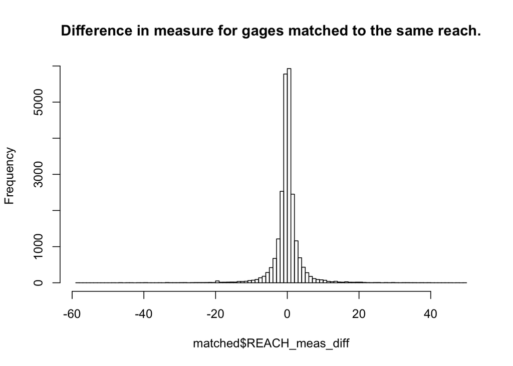

```r
matched <- cbind(indexes, dplyr::select(sf::st_set_geometry(gages, NULL), REACHCODE_ref = REACHCODE, COMID_ref = FLComID, REACH_meas_ref = Measure)) %>%
  dplyr::filter(REACHCODE == REACHCODE_ref) %>%
  dplyr::mutate(REACH_meas_diff = REACH_meas - REACH_meas_ref)

hist(matched$REACH_meas_diff, breaks = 100, main = "Difference in measure for gages matched to the same reach.")
```

```r
round(quantile(matched$REACH_meas_diff, probs = c(0, 0.1, 0.25, 0.5, 0.75, 0.9, 1)), digits = 2)
```

```
##     0%    10%    25%    50%    75%    90%   100%
## -58.09  -2.89  -1.03   0.00   0.99   2.90  49.39
```

The above example used the native nodes of the NHDPlus as the potential measure snap locations. The `nhdplusTools::get_flowline_index()` function has the ability to refine these by segmentizing the line to some given resolution. Let’s try the same thing using a resolution of 10m and see if we can do any better.

Note that the `sf::st_segmentize` function takes care of the distance conversion and segmentizes our lon/lat lines to 10m on the fly.

```r
timer <- Sys.time()
indexes <- get_flowline_index(flowlines, gages$Shape, search_radius = 0.1, precision = 10)
Sys.time()-timer
```

```
## Time difference of 10.44629 mins
```

Now lets look at out comparison again.

```r
p_match <- 100 * length(which(indexes$COMID %in% gages$FLComID)) / nrow(gages)
paste0(round(p_match, digits = 1), "% were found to match the COMID in the NHDPlus gages layer")
```

```
## [1] "85.1% were found to match the COMID in the NHDPlus gages layer"
```

```r
p_match <- 100 * length(which(indexes$REACHCODE %in% gages$REACHCODE)) / nrow(gages)
paste0(round(p_match, digits = 1), "% were found to match the REACHCODE in the NHDPlus gages layer")
```

```
## [1] "85.9% were found to match the REACHCODE in the NHDPlus gages layer"
```

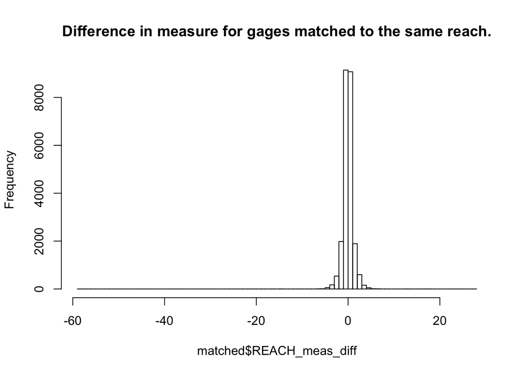

```r
matched <- cbind(indexes, dplyr::select(sf::st_set_geometry(gages, NULL), REACHCODE_ref = REACHCODE, COMID_ref = FLComID, REACH_meas_ref = Measure)) %>%
  dplyr::filter(REACHCODE == REACHCODE_ref) %>%
  dplyr::mutate(REACH_meas_diff = REACH_meas - REACH_meas_ref)

hist(matched$REACH_meas_diff, breaks = 100, main = "Difference in measure for gages matched to the same reach.")
```

```r
round(quantile(matched$REACH_meas_diff, probs = c(0, 0.1, 0.25, 0.5, 0.75, 0.9, 1)), digits = 2)
```

```
##     0%    10%    25%    50%    75%    90%   100%
## -58.09  -1.14  -0.43   0.00   0.42   1.11  27.23
```